# Model building homework

```r
library(tidyverse)
```

```r
summary(house_data)
```

```
      id                 date                         price
 Length:21613       Min.   :2014-05-02 00:00:00   Min.   :  75000
 Class :character   1st Qu.:2014-07-22 00:00:00   1st Qu.: 321950
 Mode  :character   Median :2014-10-16 00:00:00   Median : 450000
                    Mean   :2014-10-29 04:38:01   Mean   : 540088
                    3rd Qu.:2015-02-17 00:00:00   3rd Qu.: 645000
                    Max.   :2015-05-27 00:00:00   Max.   :7700000
    bedrooms        bathrooms      sqft_living       sqft_lot
 Min.   : 0.000   Min.   :0.000   Min.   :  290   Min.   :    520
 1st Qu.: 3.000   1st Qu.:1.750   1st Qu.: 1427   1st Qu.:   5040
 Median : 3.000   Median :2.250   Median : 1910   Median :   7618
 Mean   : 3.371   Mean   :2.115   Mean   : 2080   Mean   :  15107
 3rd Qu.: 4.000   3rd Qu.:2.500   3rd Qu.: 2550   3rd Qu.:  10688
 Max.   :33.000   Max.   :8.000   Max.   :13540   Max.   :1651359
     floors        waterfront            view          condition
 Min.   :1.000   Min.   :0.000000   Min.   :0.0000   Min.   :1.000
 1st Qu.:1.000   1st Qu.:0.000000   1st Qu.:0.0000   1st Qu.:3.000
 Median :1.500   Median :0.000000   Median :0.0000   Median :3.000
 Mean   :1.494   Mean   :0.007542   Mean   :0.2343   Mean   :3.409
 3rd Qu.:2.000   3rd Qu.:0.000000   3rd Qu.:0.0000   3rd Qu.:4.000
 Max.   :3.500   Max.   :1.000000   Max.   :4.0000   Max.   :5.000
     grade          sqft_above   sqft_basement       yr_built     yr_renovated
 Min.   : 1.000   Min.   : 290   Min.   :   0.0   Min.   :1900   Min.   :   0.0
 1st Qu.: 7.000   1st Qu.:1190   1st Qu.:   0.0   1st Qu.:1951   1st Qu.:   0.0
 Median : 7.000   Median :1560   Median :   0.0   Median :1975   Median :   0.0
 Mean   : 7.657   Mean   :1788   Mean   : 291.5   Mean   :1971   Mean   :  84.4
 3rd Qu.: 8.000   3rd Qu.:2210   3rd Qu.: 560.0   3rd Qu.:1997   3rd Qu.:   0.0
 Max.   :13.000   Max.   :9410   Max.   :4820.0   Max.   :2015   Max.   :2015.0
    zipcode           lat             long        sqft_living15    sqft_lot15
 Min.   :98001   Min.   :47.16   Min.   :-122.5   Min.   : 399   Min.   :   651
 1st Qu.:98033   1st Qu.:47.47   1st Qu.:-122.3   1st Qu.:1490   1st Qu.:  5100
 Median :98065   Median :47.57   Median :-122.2   Median :1840   Median :  7620
 Mean   :98078   Mean   :47.56   Mean   :-122.2   Mean   :1987   Mean   : 12768
 3rd Qu.:98118   3rd Qu.:47.68   3rd Qu.:-122.1   3rd Qu.:2360   3rd Qu.: 10083
 Max.   :98199   Max.   :47.78   Max.   :-121.3   Max.   :6210   Max.   :871200
```

You might like to think about removing some or all of date, id, sqft_living15, sqft_lot15 and zipcode (lat and long provide a better measure of location in any event).

```r
#library(forcats)
house_data_tidy <- house_data %>%
  mutate(waterfront = ifelse(waterfront == 1, TRUE, FALSE),
         renovated = ifelse(yr_renovated == 0, FALSE, TRUE)) %>%
  mutate(condition = as_factor(condition)) %>%
  mutate(grade = as_factor(grade)) %>%
  dplyr::select(-c(id, date, sqft_living15, sqft_lot15, yr_renovated))

glimpse(house_data_tidy)
```

```
Rows: 21,613
Columns: 17
$ price         <dbl> 221900, 538000, 180000, 604000, 510000, 1225000, 257500, …
$ bedrooms      <dbl> 3, 3, 2, 4, 3, 4, 3, 3, 3, 3, 3, 2, 3, 3, 5, 4, 3, 4, 2, …
$ bathrooms     <dbl> 1.00, 2.25, 1.00, 3.00, 2.00, 4.50, 2.25, 1.50, 1.00, 2.5…
$ sqft_living   <dbl> 1180, 2570, 770, 1960, 1680, 5420, 1715, 1060, 1780, 1890…
$ sqft_lot      <dbl> 5650, 7242, 10000, 5000, 8080, 101930, 6819, 9711, 7470, …
$ floors        <dbl> 1.0, 2.0, 1.0, 1.0, 1.0, 1.0, 2.0, 1.0, 1.0, 2.0, 1.0, 1.…
$ waterfront    <lgl> FALSE, FALSE, FALSE, FALSE, FALSE, FALSE, FALSE, FALSE, F…
$ view          <dbl> 0, 0, 0, 0, 0, 0, 0, 0, 0, 0, 0, 0, 0, 0, 0, 3, 0, 0, 0, …
$ condition     <fct> 3, 3, 3, 5, 3, 3, 3, 3, 3, 3, 3, 4, 4, 4, 3, 3, 3, 4, 4, …
$ grade         <fct> 7, 7, 6, 7, 8, 11, 7, 7, 7, 7, 8, 7, 7, 7, 7, 9, 7, 7, 7,…
$ sqft_above    <dbl> 1180, 2170, 770, 1050, 1680, 3890, 1715, 1060, 1050, 1890…
$ sqft_basement <dbl> 0, 400, 0, 910, 0, 1530, 0, 0, 730, 0, 1700, 300, 0, 0, 0…
$ yr_built      <dbl> 1955, 1951, 1933, 1965, 1987, 2001, 1995, 1963, 1960, 200…
$ zipcode       <dbl> 98178, 98125, 98028, 98136, 98074, 98053, 98003, 98198, 9…
$ lat           <dbl> 47.5112, 47.7210, 47.7379, 47.5208, 47.6168, 47.6561, 47.…
$ long          <dbl> -122.257, -122.319, -122.233, -122.393, -122.045, -122.00…
$ renovated     <lgl> FALSE, TRUE, FALSE, FALSE, FALSE, FALSE, FALSE, FALSE, FA…
```

- I kept zipcode, because it is likely to provide easier overview of how the price varies based on location in the city. I changed waterfront to logical and yr_renovated to logical renovated.

condition is a categorical variable on a scale 1 - 5.

```r
sort(unique(house_data$condition))
```

```
[1] 1 2 3 4 5
```

grade is also categorical on a scale 1 - 13, however grade 2 is not present.

```r
sort(unique(house_data$grade))
```

```
 [1]  1  3  4  5  6  7  8  9 10 11 12 13
```

Check for aliased variables

```r
alias(lm(price ~ ., data = house_data_tidy))
```

```
Model :
price ~ bedrooms + bathrooms + sqft_living + sqft_lot + floors +
    waterfront + view + condition + grade + sqft_above + sqft_basement +
    yr_built + zipcode + lat + long + renovated

Complete :
              (Intercept) bedrooms bathrooms sqft_living sqft_lot floors
sqft_basement  0           0        0         1           0        0
              waterfrontTRUE view condition2 condition3 condition4 condition5
sqft_basement  0              0    0          0          0          0
              grade3 grade4 grade5 grade6 grade7 grade8 grade9 grade10 grade11
sqft_basement  0      0      0      0      0      0      0      0       0
              grade12 grade13 sqft_above yr_built zipcode lat long renovatedTRUE
sqft_basement  0       0      -1          0        0       0   0    0
```

It looks like variables sqft_living and sqft_above are aliased, so I will remove sqft_above from the model.

```r
house_data_tidy <- house_data_tidy %>%
  dplyr::select(-c(sqft_above))
alias(lm(price ~ ., data = house_data_tidy))
```

```
Model :
price ~ bedrooms + bathrooms + sqft_living + sqft_lot + floors +
    waterfront + view + condition + grade + sqft_basement + yr_built +
    zipcode + lat + long + renovated
```

```r
glimpse(house_data_tidy)
```

```
Rows: 21,613
Columns: 16
$ price         <dbl> 221900, 538000, 180000, 604000, 510000, 1225000, 257500, …
$ bedrooms      <dbl> 3, 3, 2, 4, 3, 4, 3, 3, 3, 3, 3, 2, 3, 3, 5, 4, 3, 4, 2, …
$ bathrooms     <dbl> 1.00, 2.25, 1.00, 3.00, 2.00, 4.50, 2.25, 1.50, 1.00, 2.5…
$ sqft_living   <dbl> 1180, 2570, 770, 1960, 1680, 5420, 1715, 1060, 1780, 1890…
$ sqft_lot      <dbl> 5650, 7242, 10000, 5000, 8080, 101930, 6819, 9711, 7470, …
$ floors        <dbl> 1.0, 2.0, 1.0, 1.0, 1.0, 1.0, 2.0, 1.0, 1.0, 2.0, 1.0, 1.…
$ waterfront    <lgl> FALSE, FALSE, FALSE, FALSE, FALSE, FALSE, FALSE, FALSE, F…
$ view          <dbl> 0, 0, 0, 0, 0, 0, 0, 0, 0, 0, 0, 0, 0, 0, 0, 3, 0, 0, 0, …
$ condition     <fct> 3, 3, 3, 5, 3, 3, 3, 3, 3, 3, 3, 4, 4, 4, 3, 3, 3, 4, 4, …
$ grade         <fct> 7, 7, 6, 7, 8, 11, 7, 7, 7, 7, 8, 7, 7, 7, 7, 9, 7, 7, 7,…
$ sqft_basement <dbl> 0, 400, 0, 910, 0, 1530, 0, 0, 730, 0, 1700, 300, 0, 0, 0…
$ yr_built      <dbl> 1955, 1951, 1933, 1965, 1987, 2001, 1995, 1963, 1960, 200…
$ zipcode       <dbl> 98178, 98125, 98028, 98136, 98074, 98053, 98003, 98198, 9…
$ lat           <dbl> 47.5112, 47.7210, 47.7379, 47.5208, 47.6168, 47.6561, 47.…
$ long          <dbl> -122.257, -122.319, -122.233, -122.393, -122.045, -122.00…
$ renovated     <lgl> FALSE, TRUE, FALSE, FALSE, FALSE, FALSE, FALSE, FALSE, FA…
```

Systematically build a regression model containing up to four main effects (remember, a main effect is just a single predictor with coefficient), testing the regression diagnostics as you go.

```r
library(GGally)
```

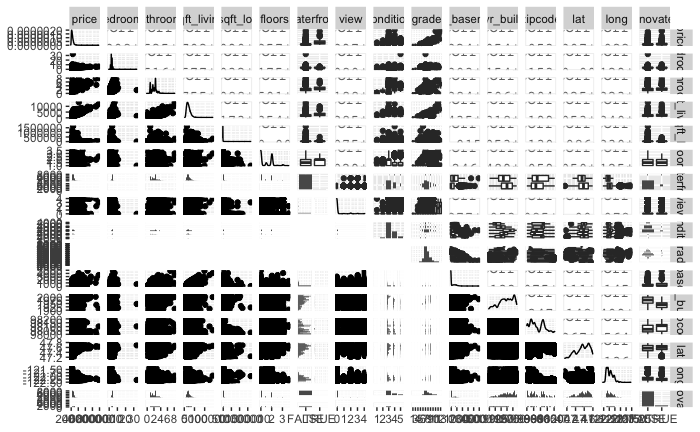

```r
ggpairs(house_data_tidy)
```

ggpairs plot is not at all helpful :(

```r
summary(lm(price ~ ., data = house_data_tidy))
```

```
Call:
lm(formula = price ~ ., data = house_data_tidy)

Residuals:
     Min       1Q   Median       3Q      Max
-1594998   -92176    -7737    72245  3916838

Coefficients:
                     Estimate     Std. Error t value             Pr(>|t|)
(Intercept)    11600305.86994  2762619.39641   4.199       0.000026914182 ***
bedrooms         -19461.74373     1836.54498 -10.597 < 0.0000000000000002 ***
bathrooms         42946.96142     3110.56978  13.807 < 0.0000000000000002 ***
sqft_living         143.26901        3.35244  42.736 < 0.0000000000000002 ***
sqft_lot             -0.05973        0.03304  -1.808             0.070687 .
floors            22195.75878     3448.41452   6.437       0.000000000125 ***
waterfrontTRUE   563397.67104    16525.94563  34.092 < 0.0000000000000002 ***
view              51159.89826     2013.15088  25.413 < 0.0000000000000002 ***
condition2        43159.54119    38525.22238   1.120             0.262601
condition3        50118.58207    35859.69143   1.398             0.162239
condition4        79862.02621    35864.23739   2.227             0.025972 *
condition5       120890.92620    36069.16891   3.352             0.000805 ***
grade3            46237.79126   223817.12727   0.207             0.836334
grade4          -115845.26615   197670.85142  -0.586             0.557847
grade5          -146763.25582   194841.49140  -0.753             0.451311
grade6          -122889.92157   194720.99362  -0.631             0.527977
grade7           -80240.74107   194738.12813  -0.412             0.680311
grade8           -14624.42248   194774.70138  -0.075             0.940149
grade9           112408.04494   194841.55379   0.577             0.563999
grade10          279961.88324   194946.66263   1.436             0.150990
grade11          527794.52823   195209.73479   2.704             0.006862 **
grade12          977459.41531   196172.18129   4.983       0.000000632006 ***
grade13         2166102.73036   202624.78955  10.690 < 0.0000000000000002 ***
sqft_basement        -5.56064        4.17492  -1.332             0.182902
yr_built          -2161.92741       70.68684 -30.585 < 0.0000000000000002 ***
zipcode            -624.30634       31.41991 -19.870 < 0.0000000000000002 ***
lat              624337.76228    10210.99034  61.144 < 0.0000000000000002 ***
long            -198910.40555    12329.59877 -16.133 < 0.0000000000000002 ***
renovatedTRUE     57639.57913     6966.97755   8.273 < 0.0000000000000002 ***
---
Signif. codes:  0 ‘***’ 0.001 ‘**’ 0.01 ‘*’ 0.05 ‘.’ 0.1 ‘ ’ 1

Residual standard error: 191300 on 21584 degrees of freedom
Multiple R-squared:  0.7289,    Adjusted R-squared:  0.7285
F-statistic:  2073 on 28 and 21584 DF,  p-value: < 0.00000000000000022
```

I will attempt to build a model with following features: sqft_living, lat, grade, waterfront, view.

```r
model1a <- lm(price ~ sqft_living, data = house_data_tidy)
summary(model1a)
```

```
Call:
lm(formula = price ~ sqft_living, data = house_data_tidy)

Residuals:
     Min       1Q   Median       3Q      Max
-1476062  -147486   -24043   106182  4362067

Coefficients:
              Estimate Std. Error t value            Pr(>|t|)
(Intercept) -43580.743   4402.690  -9.899 <0.0000000000000002 ***
sqft_living    280.624      1.936 144.920 <0.0000000000000002 ***
---
Signif. codes:  0 ‘***’ 0.001 ‘**’ 0.01 ‘*’ 0.05 ‘.’ 0.1 ‘ ’ 1

Residual standard error: 261500 on 21611 degrees of freedom
Multiple R-squared:  0.4929,    Adjusted R-squared:  0.4928
F-statistic: 2.1e+04 on 1 and 21611 DF,  p-value: < 0.00000000000000022
```

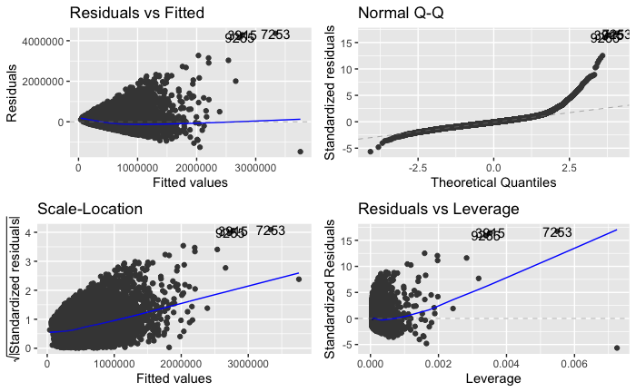

```r
library(ggfortify)
autoplot(model1a)
```

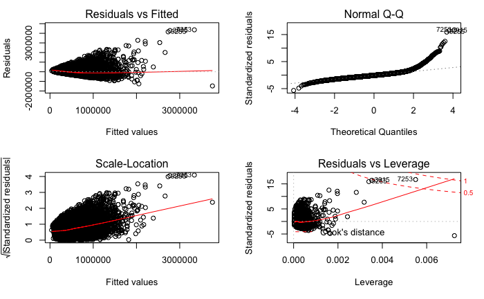

```r
par(mfrow = c(2,2))
plot(model1a)
```

```r
model1b <- lm(price ~ lat, data = house_data_tidy)
summary(model1b)
```

```
Call:
lm(formula = price ~ lat, data = house_data_tidy)

Residuals:
    Min      1Q  Median      3Q     Max
-592474 -183761  -76713   78364 7103178

Coefficients:
             Estimate Std. Error t value            Pr(>|t|)
(Intercept) -38145810     815789  -46.76 <0.0000000000000002 ***
lat            813412      17153   47.42 <0.0000000000000002 ***
---
Signif. codes:  0 ‘***’ 0.001 ‘**’ 0.01 ‘*’ 0.05 ‘.’ 0.1 ‘ ’ 1

Residual standard error: 349400 on 21611 degrees of freedom
Multiple R-squared:  0.09425,   Adjusted R-squared:  0.09421
F-statistic:  2249 on 1 and 21611 DF,  p-value: < 0.00000000000000022
```

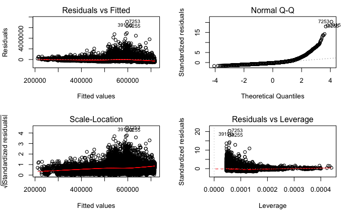

```r
par(mfrow = c(2,2))
plot(model1b)
```

```r
model2a <- lm(price ~ sqft_living + waterfront, data = house_data_tidy)
summary(model2a)
```

```
Call:
lm(formula = price ~ sqft_living + waterfront, data = house_data_tidy)

Residuals:
     Min       1Q   Median       3Q      Max
-1376782  -142867   -21360   107201  4449253

Coefficients:
                 Estimate Std. Error t value             Pr(>|t|)
(Intercept)    -32957.851   4242.971  -7.768  0.00000000000000835 ***
sqft_living       272.507      1.873 145.499 < 0.0000000000000002 ***
waterfrontTRUE 829983.104  19882.279  41.745 < 0.0000000000000002 ***
---
Signif. codes:  0 ‘***’ 0.001 ‘**’ 0.01 ‘*’ 0.05 ‘.’ 0.1 ‘ ’ 1

Residual standard error: 251500 on 21610 degrees of freedom
Multiple R-squared:  0.5307,    Adjusted R-squared:  0.5307
F-statistic: 1.222e+04 on 2 and 21610 DF,  p-value: < 0.00000000000000022
```

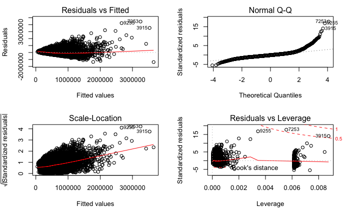

```r
par(mfrow = c(2,2))
plot(model2a)
```

```r
model2b <- lm(price ~ sqft_living + view, data = house_data_tidy)
summary(model2b)
```

```
Call:
lm(formula = price ~ sqft_living + view, data = house_data_tidy)

Residuals:
     Min       1Q   Median       3Q      Max
-1583570  -139453   -19322   104245  4321083

Coefficients:
              Estimate Std. Error t value             Pr(>|t|)
(Intercept) -16853.463   4257.279  -3.959            0.0000756 ***
sqft_living    256.176      1.934 132.485 < 0.0000000000000002 ***
view        102951.162   2317.467  44.424 < 0.0000000000000002 ***
---
Signif. codes:  0 ‘***’ 0.001 ‘**’ 0.01 ‘*’ 0.05 ‘.’ 0.1 ‘ ’ 1

Residual standard error: 250300 on 21610 degrees of freedom
Multiple R-squared:  0.5353,    Adjusted R-squared:  0.5352
F-statistic: 1.245e+04 on 2 and 21610 DF,  p-value: < 0.00000000000000022
```

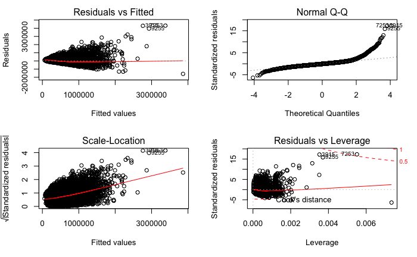

```r
par(mfrow = c(2,2))
plot(model2b)
```

```r
model2c <- lm(price ~ sqft_living + renovated, data = house_data_tidy)
summary(model2c)
```

```
Call:
lm(formula = price ~ sqft_living + renovated, data = house_data_tidy)

Residuals:
     Min       1Q   Median       3Q      Max
-1447169  -146107   -23192   106324  4228135

Coefficients:
                Estimate Std. Error t value            Pr(>|t|)
(Intercept)   -46328.631   4372.000  -10.60 <0.0000000000000002 ***
sqft_living      278.693      1.925  144.80 <0.0000000000000002 ***
renovatedTRUE 159947.478   8783.478   18.21 <0.0000000000000002 ***
---
Signif. codes:  0 ‘***’ 0.001 ‘**’ 0.01 ‘*’ 0.05 ‘.’ 0.1 ‘ ’ 1

Residual standard error: 259500 on 21610 degrees of freedom
Multiple R-squared:  0.5005,    Adjusted R-squared:  0.5005
F-statistic: 1.083e+04 on 2 and 21610 DF,  p-value: < 0.00000000000000022
```

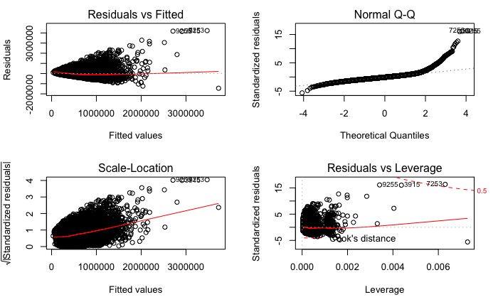

```r
par(mfrow = c(2,2))
plot(model2c)
```

```r
anova(model1a, model2b)
```

```
Analysis of Variance Table

Model 1: price ~ sqft_living
Model 2: price ~ sqft_living + view
  Res.Df              RSS Df       Sum of Sq      F                Pr(>F)
1  21611 1477276362322490
2  21610 1353656323907222  1 123620038415268 1973.5 < 0.00000000000000022 ***
---
Signif. codes:  0 ‘***’ 0.001 ‘**’ 0.01 ‘*’ 0.05 ‘.’ 0.1 ‘ ’ 1
```

```r
model3a <- lm(price ~ sqft_living + view + waterfront, data = house_data_tidy)
summary(model3a)
```

```
Call:
lm(formula = price ~ sqft_living + view + waterfront, data = house_data_tidy)

Residuals:
     Min       1Q   Median       3Q      Max
-1487434  -138469   -18344   104874  4391875

Coefficients:
                 Estimate Std. Error t value             Pr(>|t|)
(Intercept)    -16322.391   4186.474  -3.899            0.0000969 ***
sqft_living       256.797      1.902 135.044 < 0.0000000000000002 ***
view            76680.750   2475.421  30.977 < 0.0000000000000002 ***
waterfrontTRUE 574358.138  21133.213  27.178 < 0.0000000000000002 ***
---
Signif. codes:  0 ‘***’ 0.001 ‘**’ 0.01 ‘*’ 0.05 ‘.’ 0.1 ‘ ’ 1

Residual standard error: 246100 on 21609 degrees of freedom
Multiple R-squared:  0.5507,    Adjusted R-squared:  0.5506
F-statistic:  8827 on 3 and 21609 DF,  p-value: < 0.00000000000000022
```

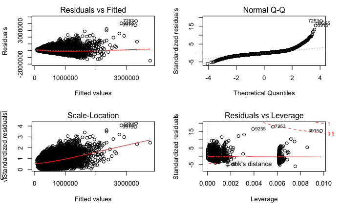

```r
par(mfrow = c(2,2))
plot(model3a)
```

```r
model3b <- lm(price ~ sqft_living + view + renovated, data = house_data_tidy)
summary(model3b)
```

```
Call:
lm(formula = price ~ sqft_living + view + renovated, data = house_data_tidy)

Residuals:
     Min       1Q   Median       3Q      Max
-1557430  -138523   -18539   105049  4216619

Coefficients:
                Estimate Std. Error t value             Pr(>|t|)
(Intercept)   -19850.776   4240.390  -4.681           0.00000287 ***
sqft_living      255.409      1.924 132.716 < 0.0000000000000002 ***
view           99761.912   2315.573  43.083 < 0.0000000000000002 ***
renovatedTRUE 126272.143   8465.284  14.916 < 0.0000000000000002 ***
---
Signif. codes:  0 ‘***’ 0.001 ‘**’ 0.01 ‘*’ 0.05 ‘.’ 0.1 ‘ ’ 1

Residual standard error: 249000 on 21609 degrees of freedom
Multiple R-squared:   0.54, Adjusted R-squared:   0.54
F-statistic:  8457 on 3 and 21609 DF,  p-value: < 0.00000000000000022
```

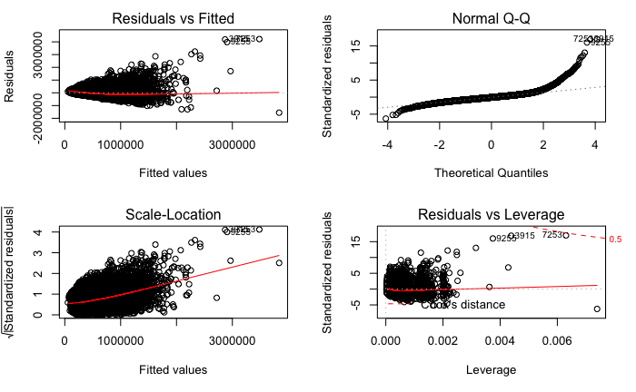

```r
par(mfrow = c(2,2))
plot(model3b)
```

```r
model3c <- lm(price ~ sqft_living + view + grade, data = house_data_tidy)
summary(model3c)
```

```
Call:
lm(formula = price ~ sqft_living + view + grade, data = house_data_tidy)

Residuals:
     Min       1Q   Median       3Q      Max
-1739583  -123735   -23485    92211  4674116

Coefficients:
               Estimate  Std. Error t value             Pr(>|t|)
(Intercept)  100668.021  228295.632   0.441              0.65925
sqft_living     142.524       2.696  52.870 < 0.0000000000000002 ***
view          89757.156    2126.356  42.212 < 0.0000000000000002 ***
grade3        19959.287  263612.840   0.076              0.93965
grade4         7198.028  232199.212   0.031              0.97527
grade5        -4531.345  228773.001  -0.020              0.98420
grade6        23101.554  228363.042   0.101              0.91942
grade7        52187.300  228337.811   0.229              0.81922
grade8       108676.845  228369.310   0.476              0.63416
grade9       225520.390  228441.902   0.987              0.32355
grade10      410645.620  228558.225   1.797              0.07240 .
grade11      677259.880  228844.684   2.959              0.00308 **
grade12     1165114.833  229982.320   5.066          0.000000409 ***
grade13     2376723.300  237695.213   9.999 < 0.0000000000000002 ***
---
Signif. codes:  0 ‘***’ 0.001 ‘**’ 0.01 ‘*’ 0.05 ‘.’ 0.1 ‘ ’ 1

Residual standard error: 228300 on 21599 degrees of freedom
Multiple R-squared:  0.6135,    Adjusted R-squared:  0.6133
F-statistic:  2638 on 13 and 21599 DF,  p-value: < 0.00000000000000022
```

```
not plotting observations with leverage one:
  19453
```

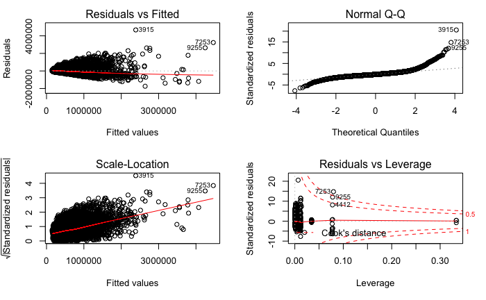

```r
par(mfrow = c(2,2))
plot(model3c)
```

```r
anova(model2b, model3c)
```

```
Analysis of Variance Table

Model 1: price ~ sqft_living + view
Model 2: price ~ sqft_living + view + grade
  Res.Df              RSS Df       Sum of Sq      F                Pr(>F)
1  21610 1353656323907222
2  21599 1125702828101685 11 227953495805537 397.62 < 0.00000000000000022 ***
---
Signif. codes:  0 ‘***’ 0.001 ‘**’ 0.01 ‘*’ 0.05 ‘.’ 0.1 ‘ ’ 1
```

```r
model4a <- lm(price ~ sqft_living + view + grade + lat , data = house_data_tidy)
summary(model4a)
```

```
Call:
lm(formula = price ~ sqft_living + view + grade + lat, data = house_data_tidy)

Residuals:
     Min       1Q   Median       3Q      Max
-1721458   -98010   -13893    65314  4594554

Coefficients:
                 Estimate    Std. Error t value             Pr(>|t|)
(Intercept) -32001376.697    533311.786 -60.005 < 0.0000000000000002 ***
sqft_living       150.307         2.466  60.957 < 0.0000000000000002 ***
view            91577.673      1942.909  47.134 < 0.0000000000000002 ***
grade3         150120.733    240853.580   0.623              0.53310
grade4          28583.345    212145.086   0.135              0.89282
grade5          10977.925    209014.670   0.053              0.95811
grade6          14351.662    208640.026   0.069              0.94516
grade7          25844.180    208617.320   0.124              0.90141
grade8          69781.591    208646.558   0.334              0.73804
grade9         174268.678    208713.503   0.835              0.40375
grade10        343758.605    208820.813   1.646              0.09974 .
grade11        596798.541    209083.647   2.854              0.00432 **
grade12       1076895.252    210123.739   5.125            0.0000003 ***
grade13       2247493.169    217175.150  10.349 < 0.0000000000000002 ***
lat            675347.096     10325.893  65.403 < 0.0000000000000002 ***
---
Signif. codes:  0 ‘***’ 0.001 ‘**’ 0.01 ‘*’ 0.05 ‘.’ 0.1 ‘ ’ 1

Residual standard error: 208600 on 21598 degrees of freedom
Multiple R-squared:  0.6774,    Adjusted R-squared:  0.6772
F-statistic:  3240 on 14 and 21598 DF,  p-value: < 0.00000000000000022
```

```
not plotting observations with leverage one:
  19453
```

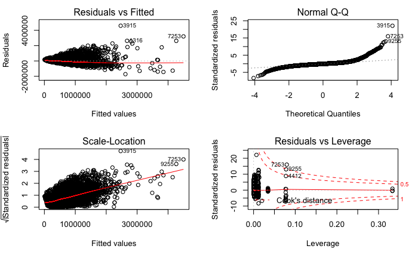

```r
par(mfrow = c(2,2))
plot(model4a)
```

```r
model4b <- lm(price ~ sqft_living + view + grade + yr_built, data = house_data_tidy)
summary(model4b)
```

```
Call:
lm(formula = price ~ sqft_living + view + grade + yr_built, data = house_data_tidy)

Residuals:
     Min       1Q   Median       3Q      Max
-1658037  -112163   -10767    87158  4527156

Coefficients:
               Estimate  Std. Error t value             Pr(>|t|)
(Intercept) 5796600.319  244590.978  23.699 < 0.0000000000000002 ***
sqft_living     144.855       2.554  56.727 < 0.0000000000000002 ***
view          71692.403    2046.254  35.036 < 0.0000000000000002 ***
grade3       -32023.997  249668.729  -0.128             0.897940
grade4       -60421.309  219919.030  -0.275             0.783516
grade5       -83620.630  216675.708  -0.386             0.699556
grade6       -36899.338  216284.975  -0.171             0.864536
grade7        52546.066  216257.725   0.243             0.808024
grade8       159210.229  216289.936   0.736             0.461680
grade9       301035.163  216361.619   1.391             0.164133
grade10      492041.532  216472.645   2.273             0.023036 *
grade11      770878.561  216745.930   3.557             0.000376 ***
grade12     1267596.708  217824.948   5.819        0.00000000599 ***
grade13     2432819.759  225122.895  10.807 < 0.0000000000000002 ***
yr_built      -2901.991      58.257 -49.814 < 0.0000000000000002 ***
---
Signif. codes:  0 ‘***’ 0.001 ‘**’ 0.01 ‘*’ 0.05 ‘.’ 0.1 ‘ ’ 1

Residual standard error: 216200 on 21598 degrees of freedom
Multiple R-squared:  0.6534,    Adjusted R-squared:  0.6531
F-statistic:  2908 on 14 and 21598 DF,  p-value: < 0.00000000000000022
```

```
not plotting observations with leverage one:
  19453
```

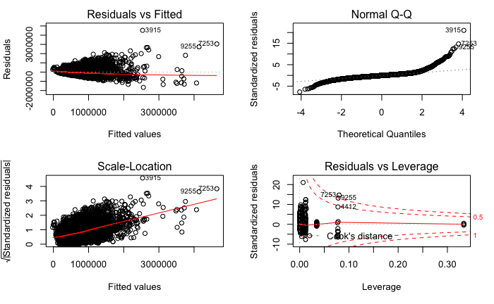

```r
par(mfrow = c(2,2))
plot(model4b)
```

*model1a seems overall better based on r-sqared value*

- model2a: price ~ sqft_living + waterfront RSE: 251500, r-sq: 0.5307
- model2b: price ~ sqft_living + view RSE: 250300, r-sq: 0.5353
- model2c: price ~ sqft_living + renovated RSE: 259500, r-sq: 0.5005

*model2b seems overal better due to r-sq*

*model3c seems better based on overall r-sq*

*model4a is better due to r-sq and diagnostic chart*

Consider possible interactions between your four main effect predictors and test their effect upon r2. Choose your best candidate interaction and visualise its effect.

```r
interact_model <- lm(price ~ sqft_living : grade + view + lat, data = house_data_tidy)
summary(interact_model)
```

```
Call:
lm(formula = price ~ sqft_living:grade + view + lat, data = house_data_tidy)

Residuals:
     Min       1Q   Median       3Q      Max
-2802932   -96100   -14771    61461  3943287

Coefficients:
                         Estimate    Std. Error t value             Pr(>|t|)
(Intercept)         -31607595.005    480653.971 -65.760 < 0.0000000000000002 ***
view                    89457.912      1902.342  47.025 < 0.0000000000000002 ***
lat                    669337.698     10100.918  66.265 < 0.0000000000000002 ***
sqft_living:grade1       -222.625       703.978  -0.316                0.752
sqft_living:grade3        200.542       196.673   1.020                0.308
sqft_living:grade4         33.277        54.759   0.608                0.543
sqft_living:grade5         56.611        13.365   4.236            0.0000229 ***
sqft_living:grade6         73.230         5.282  13.863 < 0.0000000000000002 ***
sqft_living:grade7        101.450         3.025  33.539 < 0.0000000000000002 ***
sqft_living:grade8        132.976         2.473  53.773 < 0.0000000000000002 ***
sqft_living:grade9        172.822         2.186  79.044 < 0.0000000000000002 ***
sqft_living:grade10       218.669         2.212  98.839 < 0.0000000000000002 ***
sqft_living:grade11       264.338         2.567 102.982 < 0.0000000000000002 ***
sqft_living:grade12       326.960         3.928  83.228 < 0.0000000000000002 ***
sqft_living:grade13       454.886         7.349  61.899 < 0.0000000000000002 ***
---
Signif. codes:  0 ‘***’ 0.001 ‘**’ 0.01 ‘*’ 0.05 ‘.’ 0.1 ‘ ’ 1

Residual standard error: 204100 on 21598 degrees of freedom
Multiple R-squared:  0.6912,    Adjusted R-squared:  0.691
F-statistic:  3453 on 14 and 21598 DF,  p-value: < 0.00000000000000022
```

```r
price_resid<- house_data_tidy %>%
  add_residuals(model4a)%>%
  dplyr::select(-price)

coplot(resid ~ sqft_living | grade + view + lat, data = price_resid, columns = 3)
```

```
‘+’ not meaningful for factorsError in bad.givens() : invalid 'given.values'
```

Calculate the relative importance of predictors from your best 4-predictor model (i.e. the model without an interaction). Which predictor affects price most strongly?

```r
calc.relimp(model4a, type = "lmg", rela = TRUE)
```

```
Response variable: price
Total response variance: 134782378397
Analysis based on 21613 observations

14 Regressors:
Some regressors combined in groups:
        Group  grade : grade3 grade4 grade5 grade6 grade7 grade8 grade9 grade10 grade11 grade12 grade13

 Relative importance of 4 (groups of) regressors assessed:
 grade sqft_living view lat

Proportion of variance explained by model: 67.74%
Metrics are normalized to sum to 100% (rela=TRUE).

Relative importance metrics:

                  lmg
grade       0.4018814
sqft_living 0.3731488
view        0.1152626
lat         0.1097071

Average coefficients for different model sizes:

                  1group      2groups      3groups      4groups
sqft_living     280.6236     229.4728     185.9936     150.3067
view         190335.2479  132249.9282  100273.6136   91577.6735
grade3        63666.6672   89005.2562  118121.6316  150120.7334
grade4        72381.0351   55818.2839   41220.3627   28583.3451
grade5       106523.9716   72035.3334   40156.8903   10977.9254
grade6       159919.6380  108930.7531   60318.2714   14351.6618
grade7       260590.2629  178969.5526  100560.3971   25844.1804
grade8       400852.7662  285518.1958  174911.3104   69781.5912
grade9       631513.1864  471886.6265  319115.0178  174268.6781
grade10      929771.0746  724953.5232  529136.7279  343758.6048
grade11     1354841.7274 1089164.1175  835840.7904  596798.5412
grade12     2049222.0006 1707046.8330 1382087.9613 1076895.2524
grade13     3567615.3852 3104380.8487 2663234.0124 2247493.1694
lat          813411.5832  719248.6682  678703.9812  675347.0960
```